# TV Onward Navigation Bar Journeys

VickyBanks

03/02/2020

# Overview

The project was looking at the onward naviagtion bar on iPlayer big screen that users access during playback of content. The menu consists of two parts: related content from the same brand or recomendations of programs regarded as similar to this brand.

The time period analysed was 2019-11-01 to 2019-11-14 and all visits to big screen where the navigation bar was click were included. During this time there were 4,813,675 (~10%) visits containing at least one click and 41,679,487 (~90%) without a click. The click was identified by the labels ‘page-section-related~select’ and ‘page-section-rec~select’ in the attribute field of the s3_audience.publosher table in SCV. Of all clicks identified 12% were to the recommended section and 88% to the related section.

# Click Destination

The hypothesis suggested that users were clicking the navigation bar as a shortcut to find their desired content so the content their click took them to was compared to the initial content. Content was split into several categories: content of a different brand entirely, content of the same brand and same series, within this if it was the next episode or not, and content of the same brand but another series again within this splitting into if content was the next episode (i.e first of a new series) or not.

To do this, each record had the brand and series IDs associated with the content ID determined using the prez.scv_vmb table and the numerical position of the episode within a series identified using the central_insights_sandbox.episode_numbers table. Content was then grouped by brand and ordered by series to number all episodes in sequence to allow the journey from the final episode of one series to the first of the next to be identified as the ‘next episode’. Multiple verison of series such as the standard content comapred to a 30 minute cutdown were defined as distict from one another.

[interactive chart not shown]

From this it can be seen that 91% of journeys continued onto another episode in the same brand, 29% of those to the next episode, and within that 11% moved to another series where the new content was not the user’s next episode. This very much indicated that users are using this menu to move between episodes of a single brand, with very few users using this as a place for descovering new content.

# Time To Click

To determine the time user’s took to click content, each action in their visit was collected from the s3_audience.publosher table in SCV. The episode ID of the content being viewed when the user clicked was found and the beginning of their viewing identified as the first time that episode ID appeared. This was identified such that if a user viewed a piece of content, then left the content and then returned, the start time would be the return time, not the initial view. The time between the start of content viewing and clicking the navigation bar was calculated in seconds.

| Menu Section | Visit ID | Time to Click (sec) | Minute Band |
| --- | --- | --- | --- |
| related-select | 3193633 | 25 | 0-1 |
| rec-select | 1907523 | 114 | 1-2 |
| related-select | 5512183 | 92 | 1-2 |
| related-select | 2203114 | 273 | 4-5 |
| rec-select | 4341902 | 468 | 7-8 |
| related-select | 6912313 | 50 | 0-1 |

The number of clicks faling within each minute was counted and is displayed below.

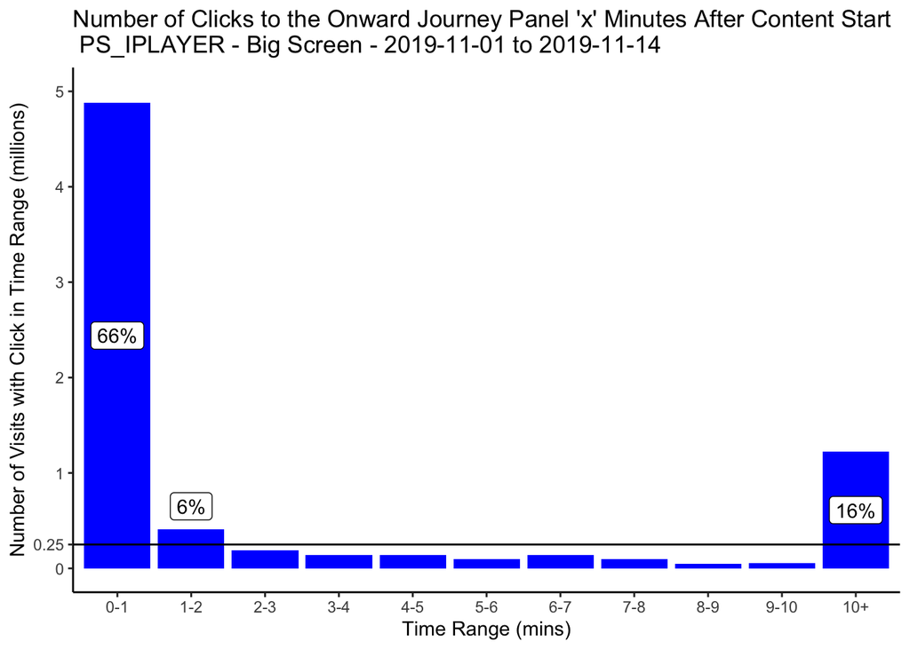

Part of the hypothesis suggested that users were specifically selecting content in order to use this navigation bar to move to other episodes. If this were correct then most clicks would occur within the first minute or two of content being viewed when users were moving to the same brand, rather than at the end of viewing that content. Similarly, this pattern should be less evident for users moving to a new brand as they would not be able to predict which brands the recomendation section would show.

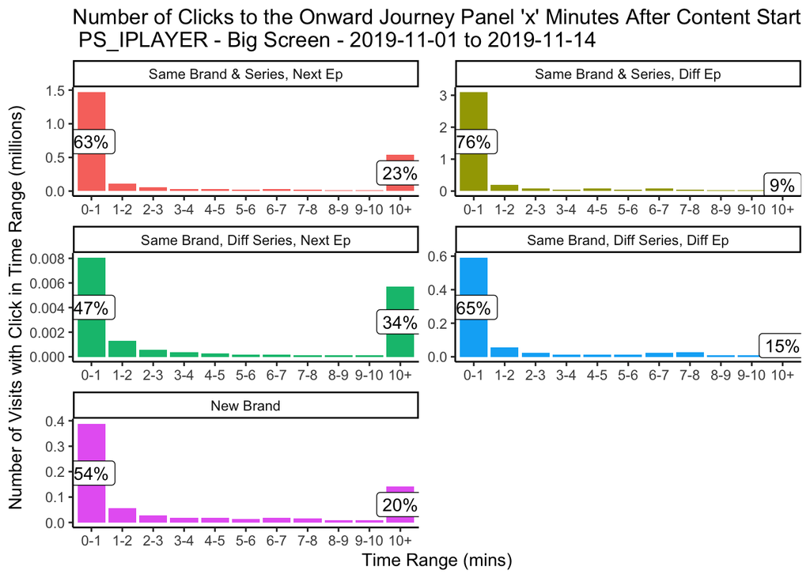